# Майнор "Интеллектуальный анализ данных"

# Курс "Введение в анализ данных"

# Лабораторная работа №1. Обработка и первичный анализ данных

## Данные

В рамках данной лабораторной работы вам предлагается проанализировать набор данных о студентах двух школ в Португалии.  
В файле `students_data.csv` представлена информация о студентах, посещающих два курса - математику (`Math`) и поргутальский язык (`Por`). Некоторые студенты представлены в обоих курсах, некоторые - только в одном. Для каждого студента известны три оценки по курсу: оценка за первое полугодие (`G1`), оценка за второе полугодие (`G2`) и итоговая оценка за год (`G3`).

```python
import pandas as pd
```

```python
pd.set_option('display.max_columns', 40)
pd.set_option('display.max_colwidth', -1)
```

```python
data = pd.read_csv("students_data.csv")
data.shape
```

```
(1044, 36)
```

```python
data.head(15)
```

|  | ID | Subject | school | sex | age | address | famsize | Pstatus | Medu | Fedu | Mjob | Fjob | reason | guardian | traveltime | studytime | failures | schoolsup | famsup | paid | activities | nursery | higher | internet | romantic | famrel | freetime | goout | Dalc | … |
| --- | --- | --- | --- | --- | --- | --- | --- | --- | --- | --- | --- | --- | --- | --- | --- | --- | --- | --- | --- | --- | --- | --- | --- | --- | --- | --- | --- | --- | --- | --- |
| 0 | 100097 | Por | GP | F | 16 | U | GT3 | A | 3 | 4 | services | other | course | father | 1 | 1 | 0 | no | no | no | no | yes | yes | yes | no | 3.0 | 2 | 1 | 1.0 | … |
| 1 | 101021 | Por | GP | F | 17 | U | GT3 | T | 3 | 2 | other | other | course | mother | 1 | 2 | 0 | no | no | no | yes | no | yes | yes | no | 5.0 | 3 | 4 | 1.0 | … |
| 2 | 102965 | Por | GP | M | 16 | U | LE3 | T | 1 | 2 | health | services | course | mother | 2 | 1 | 2 | no | no | no | no | no | yes | yes | no | 4.0 | 4 | 5 | 3.0 | … |
| 3 | 102989 | Por | MS | M | 17 | U | GT3 | T | 2 | 3 | other | services | home | father | 2 | 2 | 0 | no | no | no | yes | yes | yes | yes | no | 4.0 | 4 | 3 | 1.0 | … |
| 4 | 103131 | Por | GP | F | 16 | U | GT3 | T | 1 | 1 | at_home | other | home | mother | 2 | 1 | 0 | no | yes | no | no | yes | yes | no | NaN | 4.0 | 3 | 2 | 1.0 | … |
| 5 | 103144 | Por | GP | M | 18 | U | LE3 | T | 3 | 1 | services | services | course | mother | 2 | 1 | 0 | no | no | no | yes | yes | yes | yes | yes | 3.0 | 3 | 4 | 4.0 | … |
| 6 | 105257 | Por | MS | F | 18 | U | GT3 | T | 1 | 1 | other | other | course | mother | 2 | 2 | 0 | no | no | no | yes | yes | yes | no | no | 1.0 | 1 | 1 | 1.0 | … |
| 7 | 107639 | Por | MS | F | 15 | R | GT3 | T | 4 | 4 | teacher | other | course | mother | 2 | 1 | 0 | no | no | no | no | yes | yes | yes | yes | 1.0 | 5 | 1 | 3.0 | … |
| 8 | 107914 | Math | GP | F | 15 | U | LE3 | T | 3 | 2 | services | other | reputation | mother | 1 | 2 | 0 | no | yes | yes | no | yes | yes | yes | no | 4.0 | 4 | 4 | 1.0 | … |
| 9 | 108089 | Por | MS | M | 16 | R | GT3 | T | 3 | 4 | other | health | other | mother | 3 | 2 | 0 | no | no | no | no | no | yes | no | no | 3.0 | 4 | 5 | 1.0 | … |
| 10 | 108254 | Por | GP | M | 15 | U | LE3 | T | 4 | 4 | health | services | course | father | 1 | 1 | 0 | no | yes | no | yes | yes | yes | yes | no | 4.0 | 3 | 3 | 1.0 | … |
| 11 | 108296 | Por | GP | M | 18 | U | LE3 | T | 3 | 4 | services | other | home | mother | 1 | 2 | 0 | no | no | no | yes | yes | yes | yes | yes | 4.0 | 3 | 3 | 1.0 | … |
| 12 | 108753 | Math | MS | F | 18 | R | GT3 | T | 4 | 4 | teacher | at-home | reputation | mother | 3 | 1 | 0 | no | yes | yes | yes | yes | yes | yes | yes | 4.0 | 4 | 3 | 2.0 | … |
| 13 | 108825 | Por | GP | M | 15 | U | GT3 | T | 4 | 3 | teacher | other | home | mother | 1 | 2 | 0 | no | yes | no | yes | yes | yes | yes | no | 4.0 | 3 | 3 | 2.0 | … |
| 14 | 114462 | Math | GP | F | 16 | U | LE3 | T | 2 | 2 | at_home | other | course | mother | 1 | 2 | 0 | no | yes | no | no | yes | yes | no | no | 4.0 | 3 | 4 | 1.0 | … |

### Признаки

Данные представлены признаками различных типов: числовыми, категориальными, упорядоченными категориальными.

**Описание признаков:**

```python
pd.read_csv('students_data_features.csv',
            delimiter=';',
            encoding='windows-1251')
```

|  | Признак | Описание |
| --- | --- | --- |
| 0 | ID | Уникальный номер наблюдения |
| 1 | Subject | Предмет: 'Math' - математика, 'Por' - португальский язык |
| 2 | school | Школа: 'GP' - Gabriel Pereira, 'MS' - Mousinho da Silveira |
| 3 | sex | Пол студента: 'F' - женский, 'M' - мужской |
| 4 | age | Возраст студента |
| 5 | address | Место проживания студента: 'U' - в городе, 'R' - за городом |
| 6 | famsize | Число членов семьи: 'LE3' - если <= 3, 'GT3' - если > 3 |
| 7 | Pstatus | Отношения родителей: 'T' - живут вместе, 'A' - живут раздельно |
| 8 | Medu | Образование матери: 0 - без образования, 1 - начальная школа, 2 – от 5 до 9 классов, 3 – среднее образование, 4 – высшее образование |
| 9 | Fedu | Образование отца: 0 - без образования, 1 - начальная школа, 2 – от 5 до 9 классов, 3 – среднее образование, 4 – высшее образование |
| 10 | Mjob | Работа матери: 'teacher' - связана с преподаванием, 'health' - связана с здравоохранением, 'services' - администрация и полиция, 'at_home' - домашняя занятость, 'other' - другое |
| 11 | Fjob | Работа отца: 'teacher' - связана с преподаванием, 'health' - связана с здравоохранением, 'services' - администрация и полиция, 'at_home' - домашняя занятость, 'other' - другое |
| 12 | reason | Причина, по которой студент выбрал данную школу: 'home' - рядом с домом, 'reputation' - репутация школы, 'course' - читаемые курсы, 'other' - другое |
| 13 | guardian | Опекун студента (student's guardian): 'mother', 'father' или 'other' |
| 14 | traveltime | Время в пути от дома до школы: 1 - < 15 мин, 2 - от 15 до 30 мин, 3 - от 30 мин до 1 часа, 4 - > 1 часа |
| 15 | studytime | Количество часов на учебу в неделю: 1 - < 2 часов, 2 - от 2 до 5 часов, 3 - от 5 до 10 часов, 4 - > 10 часов |
| 16 | failures | Число завалов студента по предыдущим курсам: n если 1<=n<3, иначе 4 |
| 17 | schoolsup | Дополнительная помощь в учебе: yes или no |
| 18 | famsup | Дополнительная помощь в учебе от членов семьи: yes или no |
| 19 | paid | Платные дополнительные занятия по соответствущему курсу ('Math' или 'Por'): yes или no |
| 20 | activities | Внеучебные активности: yes или no |
| 21 | nursery | Ходил в детстве в детский сад: yes или no |
| 22 | higher | Собирается получать высшее образование: yes или no |
| 23 | internet | Есть доступ к всемирной сети из дома: yes или no |
| 24 | romantic | Состоит в романтических отношениях: yes или no |
| 25 | famrel | Отношения в семье: от 1 - очень плохие, до 5 - прекрасные |
| 26 | freetime | Свободное время после занятий: от 1 - очень мало, до 5 - очень много |
| 27 | goout | Проводит время с друзьями: от 1 - очень редко/мало, до 5 - очень часто/много |
| 28 | Dalc | Потребление алкоголя в будни: от 1 - очень мало, до 5 - очень много |
| 29 | Walc | Потребление алкоголя в выходные: от 1 - очень мало, до 5 - очень много |
| 30 | health | Состояние здоровья: от 1 - очень плохое, до 5 - очень хорошее |
| 31 | absences | Число пропусков: сколько раз пропустил занятия в школе |
| 32 | cheating | Списывает ли на тестах: yes или no |
| 33 | G1 | Оценка за первое полугодние: от 0 до 20 |
| 34 | G2 | Оценка за второе полугодие: от 0 до 20 |
| 35 | G3 | Итоговая оценка: от 0 до 20 |

## Задания

**NB:** Обратите внимание, что часть студентов посещают оба курса и представлены в данных два раза. Из-за этого некоторые результаты анализа могут быть искажены. Имеет смысл выявить таких студентов заранее (Задание 10) и учитывать эту информацию при анализе.

### Задание 1

- Для каждого признака определите, к какому типу он относится.
- Проверьте значения признаков на наличие опечаток и ошибок, исправьте их.  
  **Note:** Исправлять ошибки нужно программно, модифицировать руками исходный файл нельзя.
- При необходимости, приведите признак к определенному вами типу.

### 1 пункт, типы признаков

```python
data[(data['Pstatus']!='A')&(data['Pstatus']!='T')].Pstatus
data = data.replace({'Pstatus':'t'}, 'T')
data[(data['Pstatus']!='A')&(data['Pstatus']!='T')].Pstatus
```

```
Series([], Name: Pstatus, dtype: object)
```

```python
data[(data['sex']!='F')&(data['sex']!='M')].sex
data = data.replace({'sex':'m'}, 'M')
data[(data['sex']!='F')&(data['sex']!='M')].sex
```

```
Series([], Name: sex, dtype: object)
```

```python
data[(data['Medu']!='0')&(data['Medu']!='1')&(data['Medu']!='2')&(data['Medu']!='3')&(data['Medu']!='4')].Medu
data = data.replace({'Medu':'o'}, '0')
data[(data['Medu']!='0')&(data['Medu']!='1')&(data['Medu']!='2')&(data['Medu']!='3')&(data['Medu']!='4')].Medu
```

```
Series([], Name: Medu, dtype: object)
```

```python
data[(data['Fedu']!='0')&(data['Fedu']!='1')&(data['Fedu']!='2')&(data['Fedu']!='3')&(data['Fedu']!='4')].Fedu
data = data.replace({'Fedu':'o'}, '0')
data[(data['Fedu']!='0')&(data['Fedu']!='1')&(data['Fedu']!='2')&(data['Fedu']!='3')&(data['Fedu']!='4')].Fedu
```

```
Series([], Name: Fedu, dtype: object)
```

```python
data[(data['Mjob']!='teacher')&(data['Mjob']!='health')&(data['Mjob']!='services')&(data['Mjob']!='at_home')&(data['Mjob']!='other')].Mjob
data = data.replace({'Mjob':'at-home'}, 'at_home')
data[(data['Mjob']!='teacher')&(data['Mjob']!='health')&(data['Mjob']!='services')&(data['Mjob']!='at_home')&(data['Mjob']!='other')].Mjob
```

```
Series([], Name: Mjob, dtype: object)
```

```python
data[(data['Fjob']!='teacher')&(data['Fjob']!='health')&(data['Fjob']!='services')&(data['Fjob']!='at_home')&(data['Fjob']!='other')].Fjob
data = data.replace({'Fjob':'at-home'}, 'at_home')
data[(data['Fjob']!='teacher')&(data['Fjob']!='health')&(data['Fjob']!='services')&(data['Fjob']!='at_home')&(data['Fjob']!='other')].Fjob
```

```
Series([], Name: Fjob, dtype: object)
```

```python
data[(data['guardian']!='mother')&(data['guardian']!='father')&(data['guardian']!='other')].guardian
data = data.replace({'guardian':'futher'}, 'father')
data[(data['guardian']!='mother')&(data['guardian']!='father')&(data['guardian']!='other')].guardian
```

```
Series([], Name: guardian, dtype: object)
```

### Задание 2

Проверьте, присутствуют ли в данных пропущенные значения. Сколько? В каких признаках?  
По каждому такому признаку предложите и обоснуйте, что делать с пропущенными значениями.

```python
data.isnull().sum()
```

```
ID            0
Subject       0
school        0
sex           0
age           0
address       0
famsize       0
Pstatus       0
Medu          0
Fedu          0
Mjob          0
Fjob          0
reason        0
guardian      0
traveltime    0
studytime     0
failures      0
schoolsup     0
famsup        0
paid          0
activities    0
nursery       0
higher        0
internet      0
romantic      10
famrel        10
freetime      0
goout         0
Dalc          10
Walc          10
health        0
absences      0
cheating      700
G1            0
G2            0
G3            0
dtype: int64
```

```python
data[['famrel', 'Dalc', 'Walc']] = data[['famrel', 'Dalc', 'Walc']].fillna(2.5)
```

```python
data = data.drop(['cheating'], axis=1)
```

```python
data['romantic'] = data['romantic'].fillna('no')
```

```python
data.isnull().sum()
```

```
ID            0
Subject       0
school        0
sex           0
age           0
address       0
famsize       0
Pstatus       0
Medu          0
Fedu          0
Mjob          0
Fjob          0
reason        0
guardian      0
traveltime    0
studytime     0
failures      0
schoolsup     0
famsup        0
paid          0
activities    0
nursery       0
higher        0
internet      0
romantic      0
famrel        0
freetime      0
goout         0
Dalc          0
Walc          0
health        0
absences      0
G1            0
G2            0
G3            0
dtype: int64
```

### Задание 3

- Посчитайте описательные статистики для числовых и для категориальных признаков.
- Сколько студентов посещают каждую из школ?
- Сколько студентов посещают математику, сколько - португальский?
- Студенты какого курса чаще заваливают экзамены?
- Сколько в среднем времени в неделю уходит на учебу по каждому предмету?
- На что чаще обращают внимание при выборе школы?

#### Запускаем сначала 10 задание, ведь выполнять третье иначе будет некорректно

```python
data_Math = pd.DataFrame(data)
data_Por = pd.DataFrame(data)
j = 0
k = 0
for i in data['Subject']:
    if i=="Por":
        data_Math = data_Math.drop(index = data_Math.index[j])
        j = j-1
    else:
        data_Por = data_Por.drop(index = data_Por.index[k])
        k = k-1
    j = j+1
    k = k+1
```

```python
new_column_list = [0]*len(data)
data['sub_bool'] = new_column_list
```

```python
list_field = ['school', 'sex', 'age', 'address', 'reason', 'Mjob', 'Pstatus', 'internet', 'Medu', 'Fedu', 'Fjob', 'famsize', 'health', 'guardian', 'traveltime', 'studytime', 'failures', 'activities', 'nursery', 'higher', 'romantic', 'famrel', 'freetime', 'goout', 'Dalc', 'Walc']
z = 0
for i in range(len(data_Math)):
    for j in range(len(data_Por)):
        z=0
        for k in list_field:
            if data_Math.iloc[i][k] == data_Por.iloc[j][k]:
                z = z+1;
            else:
                break
        if z==26:
            data.loc[data_Math.index[i], 'sub_bool'] = 1
            break
```

```python
df_no_repeat = data
for i in range(1044):
    if data['sub_bool'][i] == 1:
        df_no_repeat = df_no_repeat.drop([i], axis=0)
```

```python
df_no_repeat.groupby(['school'])['ID'].count()
```

```
school
GP    506
MS    240
Name: ID, dtype: int64
```

506 человека - GP, 240 - MS

```python
df_no_repeat.groupby(['Subject'])['ID'].count()
```

```
Subject
Math    97
Por     649
Name: ID, dtype: int64
```

97 студентов посещают математику, 649 - португальский

```python
n_m = 0
n_p = 0
for i in range(4):
    n_m = n_m + df_no_repeat.groupby(['Subject','failures'])['ID'].count()[i]
for j in range(4, 8):
    n_p = n_p + df_no_repeat.groupby(['Subject','failures'])['ID'].count()[j]

print(df_no_repeat.groupby(['Subject','failures'])['ID'].count())
print(n_m, n_p)

por_pr = df_no_repeat.groupby(['Subject','failures'])['ID'].count()[4]/n_p
print(por_pr)

por_m = df_no_repeat.groupby(['Subject','failures'])['ID'].count()[0]/n_m
print(por_m)
```

```
Subject  failures
Math     0           30
         1           38
         2           17
         3           12
Por      0           549
         1           70
         2           16
         3           14
Name: ID, dtype: int64
97 649
0.8459167950693375
0.30927835051546393
```

Студенты математического курса чаще заваливают экзамены, так как процент успеха у "португальцев" больше.

```python
hoursM = 0
hoursP = 0
sumM = sum(data_no_rep.groupby(['Subject','studytime'])['ID'].count()[:4])
sumP = sum(data_no_rep.groupby(['Subject','studytime'])['ID'].count()[4:])
for i in [1,2,3,4]:
    hoursM = hoursM+(data_no_rep.groupby(['Subject','studytime'])['ID'].count()[i-1])*i
    hoursP = hoursP+(data_no_rep.groupby(['Subject','studytime'])['ID'].count()[i+3])*i
print(hoursM/sumM)
print(hoursP/sumP)
```

```
1.8556701030927836
1.9306625577812018
```

```python
print(data.groupby(['reason'])['ID'].count())
```

```
reason
course        430
home          258
other         108
reputation    248
Name: ID, dtype: int64
```

Ответ: курс

### Задание 4

Оцените распределение оценок (отдельно для `G1`, `G2` и `G3`). Сравните распределения для разных предметов - математики и португальского языка. Сделайте выводы.

**Tip:** Для выполнения задания пригодятся графики плотности, гистограммы и боксплоты.

```python
import pandas as pd
import numpy as np
from pandas.plotting import scatter_matrix
import matplotlib.pyplot as plt
import seaborn as sns
import copy
```

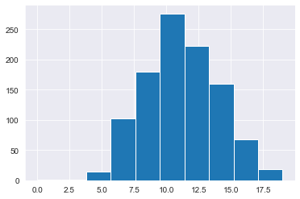

```python
h = data['G1'].hist()
fig = h.get_figure()
```

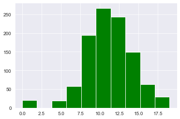

```python
h = data['G2'].hist(color = 'green')
fig = h.get_figure()
```

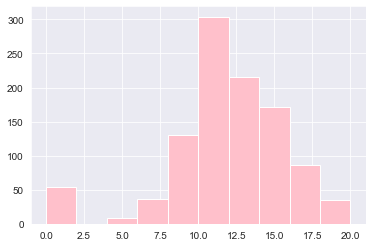

```python
h = data['G3'].hist(color = 'pink')
fig = h.get_figure()
```

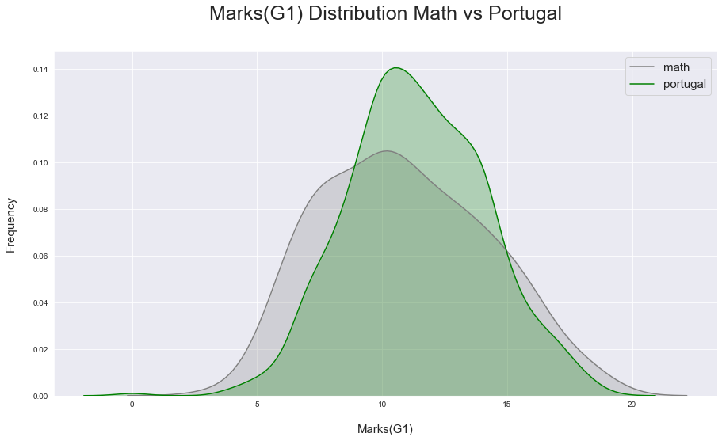

```python
g1_math = data_Math["G1"]
g1_por = data_Por["G1"]

fig = plt.figure(figsize=(15,8),)
ax=sns.kdeplot(g1_math, color='gray',shade=True,label='math')
ax=sns.kdeplot(g1_por, color='green',shade=True, label='portugal')
plt.title('Marks(G1) Distribution Math vs Portugal', fontsize = 25, pad = 40)
plt.ylabel("Frequency", fontsize = 15, labelpad = 20)
plt.xlabel("Marks(G1)", fontsize = 15, labelpad = 20)
plt.legend(fontsize = 15)
plt.show()
```

Выводы: наиболее частая оценка за первое полугодие среди студентов на курсе португальского составляет примерно 11, у "математиков" - примерно 10-11, чуть-чуть поменьше. Не удовлетворительные оценки (от 0 до 8) получали чаще "математики", от 8 до 15 - "португальцы", от 15 до 20 - опять с математического курса.

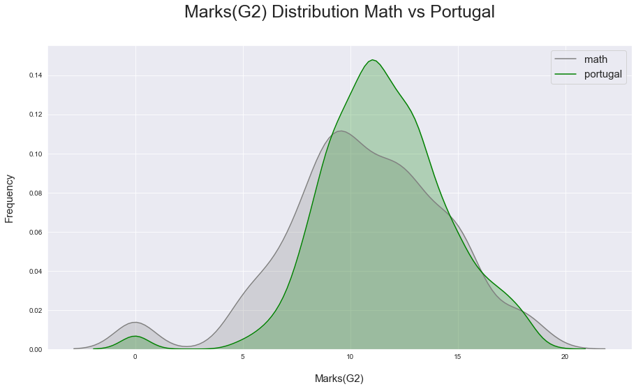

```python
g2_math = data_Math["G2"]
g2_por = data_Por["G2"]

fig = plt.figure(figsize=(15,8),)
ax=sns.kdeplot(g2_math, color='gray',shade=True,label='math')
ax=sns.kdeplot(g2_por, color='green',shade=True, label='portugal')
plt.title('Marks(G2) Distribution Math vs Portugal', fontsize = 25, pad = 40)
plt.ylabel("Frequency", fontsize = 15, labelpad = 20)
plt.xlabel("Marks(G2)", fontsize = 15, labelpad = 20)
plt.legend(fontsize = 15)
plt.show()
```

Выводы: наиболее частая оценка за второе полугодие среди студентов на курсе португальского составляет примерно 11-12, у "математиков" - примерно 9-10. Оценки от 0 до 9 получали чаще "математики", от 9 до 14 - "португальцы", от 14 до 20 примерно одинаковое количесво человек с двух курсов. Примечательно, что оценку 0 ровно во втором полугодии получило больше человек по сравнению с первым.

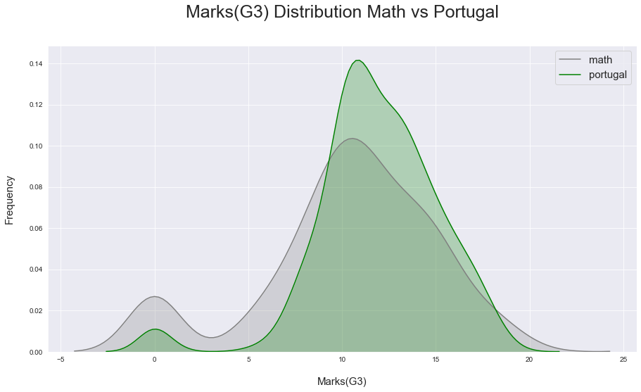

```python
g3_math = data_Math["G3"]
g3_por = data_Por["G3"]

fig = plt.figure(figsize=(15,8),)
ax=sns.kdeplot(g3_math, color='gray',shade=True,label='math')
ax=sns.kdeplot(g3_por, color='green',shade=True, label='portugal')
plt.title('Marks(G3) Distribution Math vs Portugal', fontsize = 25, pad = 40)
plt.ylabel("Frequency", fontsize = 15, labelpad = 20)
plt.xlabel("Marks(G3)", fontsize = 15, labelpad = 20)
plt.legend(fontsize = 15)
plt.show()
```

Выводы: наиболее частая итоговая оценка среди студентов на курсе португальского составляет 11, у "математиков" - примерно 10-11, чуть поменьше. Оценки от 0 до 9 получали чаще "математики", от 9 до 18 - "португальцы", от 18 до 20 - опять с математического курса. Примечательно, что оценка 0 ровно является довольно популярной среди студентов, особенно "математиков".

### Задание 5

Оцените попарные зависимости числовых признаков.  
Рассчитайте и провизуализируйте матрицу корреляций. Дайте содержательный комментарий.

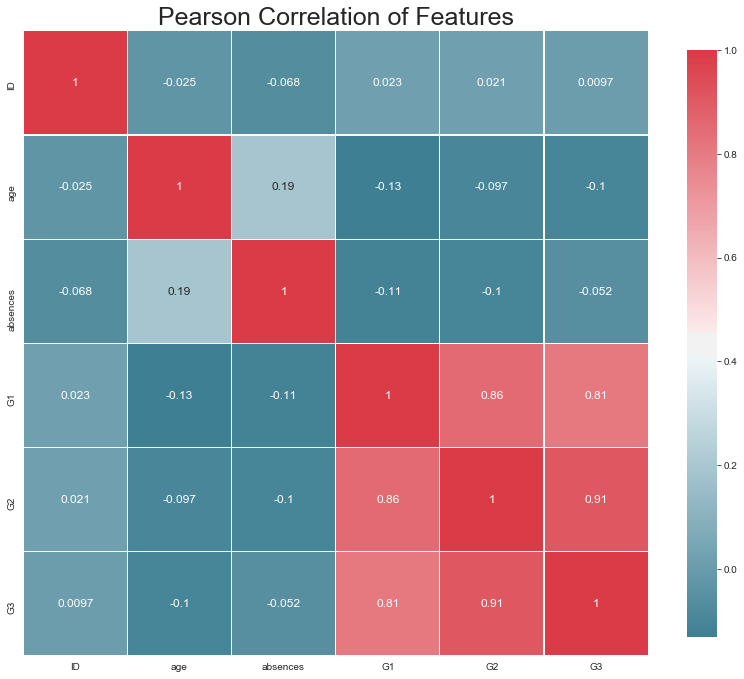

```python
d_num = pd.DataFrame({})
d_num['ID'] = df_no_repeat['ID']
d_num['age'] = df_no_repeat['age']
d_num['absences'] = df_no_repeat['absences']
d_num['G1'] = df_no_repeat['G1']
d_num['G2'] = df_no_repeat['G2']
d_num['G3'] =df_no_repeat['G3']

def correlation_heatmap(df):
    _ , ax = plt.subplots(figsize =(14, 12))
    colormap = sns.diverging_palette(220, 10, as_cmap = True)

    _ = sns.heatmap(
        df.corr(),
        cmap = colormap,
        square=True,
        cbar_kws={'shrink':.9 },
        ax=ax,
        annot=True,
        linewidths=0.1,vmax=1.0, linecolor='white',
        annot_kws={'fontsize':12 }
    )
    plt.ylim((d_num.corr().shape[0], 0))
    plt.title('Pearson Correlation of Features', size=25)

correlation_heatmap(d_num)
```

Признаки, на пересечении которых находится красный квадрат, - взаимосвязаны, и можно предсказать поведение одного через другой. Близкий к нулю коэффициент(голубые квадраты) корреляции же говорит о практически независимости данных признаков. В данном случае четко показано, что, например, итоговая оценка зависит от оценок за первое и второе полугодия.

### Задание 6

Оцените попарные зависимости нечисловых (категориальных) признаков, дайте содержательный комментарий.

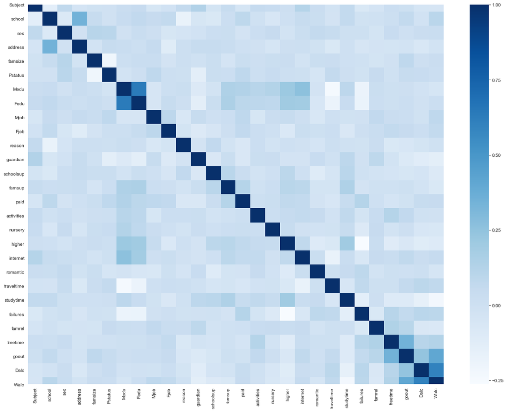

```python
data_describe = df_no_repeat.describe(include=[object])
categorical_columns = [c for c in df_no_repeat.columns if df_no_repeat[c].dtype.name == 'object']

non_data = pd.DataFrame(df_no_repeat[categorical_columns])
non_data['Fedu'] = non_data.Fedu.astype('int64')
non_data['Medu'] = non_data.Medu.astype('int64')
categorical_columns.remove('Medu')
categorical_columns.remove('Fedu')
for c in categorical_columns:
    q = range(1, 1 + non_data[c].describe(include=[object])['unique'])
    unique = dict(zip(non_data[c].unique(), q))
    tmp = non_data[c].values.tolist()
    if (q[-1] == 2) & ((tmp[0] == 'no') | (tmp[0] == 'yes')):
        yes_no = {'yes': 1, 'no': 0}
        non_data[c] = df_no_repeat[c].map(yes_no)
    else:
        for i in range(len(tmp)):
            tmp[i] = unique[tmp[i]]
        non_data[c] = pd.DataFrame(tmp)

non_data[['traveltime', 'studytime', 'failures', 'famrel','freetime',
          'goout', 'Dalc', 'Walc']] = data_no_rep[['traveltime',
        'studytime', 'failures', 'famrel','freetime','goout', 'Dalc', 'Walc']]

corr = non_data.corr()
plt.figure(figsize = (20,15))
sns.heatmap(corr, xticklabels=corr.columns.values, yticklabels=corr.columns.values, cmap = 'Blues')
```

Признаки, на пересечении которых находится синий квадрат более темного цвета, - взаимосвязаны, и можно предсказать поведение одного через другой. Близкий к нулю коэффициент(светло-голубые квадраты) корреляции же говорит о практически независимости данных признаков. В данном случае четко показано, что, например, образование матери коррелирует с образованием отца, употребление алкоголя в будни коррелирует с употреблением алкоголя в выходные, адрес со школой, свободное время с гулянками, все как в жизни.

### Задание 7

- Оцените, есть ли разница в употреблении алкоголя между парнями и девушками. Кто пьет больше?
- Оцените связь употребления алкоголя с признаками: address, Pstatus, higher, romantic, freetime.
- Оцените связь употребления алкоголя с уровнем образования опекуна (для случаев, где это известно).
- Сравните употребление алкоголя для 50 лучших учеников и 50 худших (по `G3`). Выполните сравнение отдельно для каждого предмета (`Math` и `Por`). Дайте содержательный комментарий.

**Tip:** для выполнения задания пригодятся боксплоты и гистограммы.

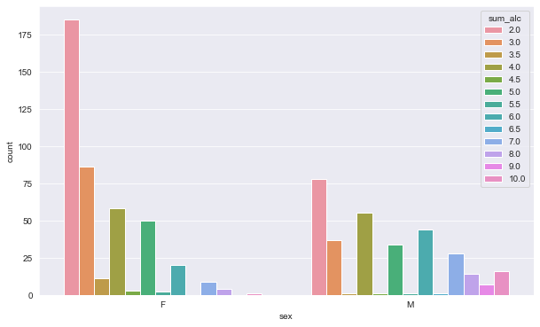

```python
sum_arr = []
for i in df_no_repeat.index:
    sum_arr.append(df_no_repeat['Walc'][i] + df_no_repeat['Dalc'][i])

df_no_repeat['sum_alc'] = sum_arr

plt.figure(figsize=(10,6))
sns.countplot(x='sex', hue='sum_alc', data=df_no_repeat)
```

Очевидно, что девушки в большинстве пьют мало (метка 2 за неделю, то есть очень мало по выходным и будням). Представители мужского пола же исключительно имеют метку 10, и в метках от 7 до 10 они имеют более высокие показатели.

Ответ: мужчины

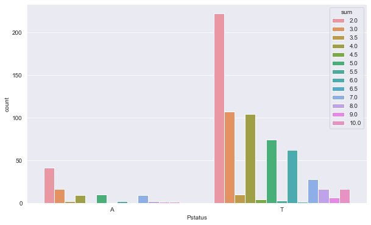

```python
plt.figure(figsize=(10,6))
sns.countplot(x='Pstatus', hue='sum', data=df_no_repeat)
```

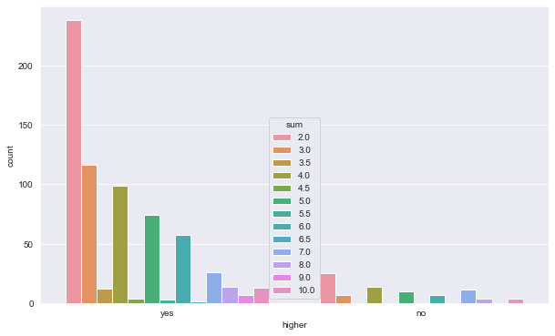

```python
plt.figure(figsize=(10,6))
sns.countplot(x='higher', hue='sum', data=df_no_repeat)
```

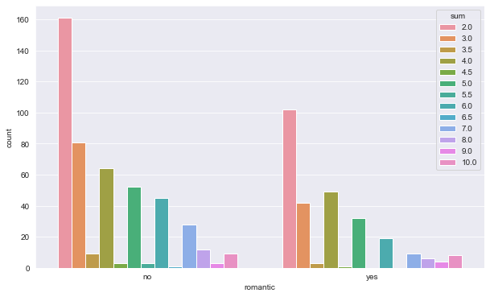

```python
plt.figure(figsize=(10,6))
sns.countplot(x='romantic', hue='sum', data=df_no_repeat)
```

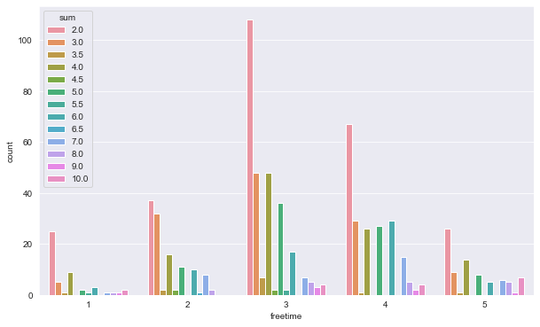

```python
plt.figure(figsize=(10,6))
sns.countplot(x='freetime', hue='sum', data=df_no_repeat)
```

### Третий пункт

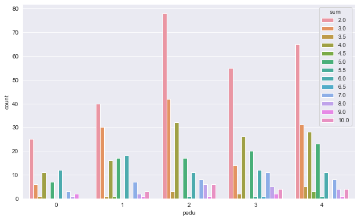

```python
arr_pedu = []
for i in df_no_repeat.index:
    if df_no_repeat['guardian'][i] == 'father':
        arr_pedu.append(df_no_repeat['Fedu'][i])
    elif df_no_repeat['guardian'][i] == 'mother':
        arr_pedu.append(df_no_repeat['Medu'][i])
    else: arr_pedu.append('0')

df_no_repeat['pedu'] = arr_pedu

plt.figure(figsize=(10,6))
sns.countplot(x='pedu', hue='sum', data=df_no_repeat)
```

### Четвертый пункт

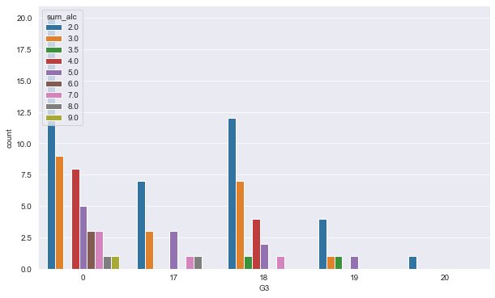

```python
sum_arr = []
for i in range(1044):
    sum_arr.append(data['Walc'][i] + data['Dalc'][i])

data['sum_alc'] = sum_arr

bl_data = data
bl_data = bl_data.sort_values('G3', ascending = False)

arr_index = []
for i in range(1044):
    arr_index.append(i)

bl_data['my_ind'] = arr_index

for i in range(1044):
    if 49 < bl_data['my_ind'][i] < 994:
        bl_data = bl_data.drop([i], axis=0)

plt.figure(figsize=(10,6))
sns.countplot(x='G3', hue='sum_alc', data=bl_data)
```

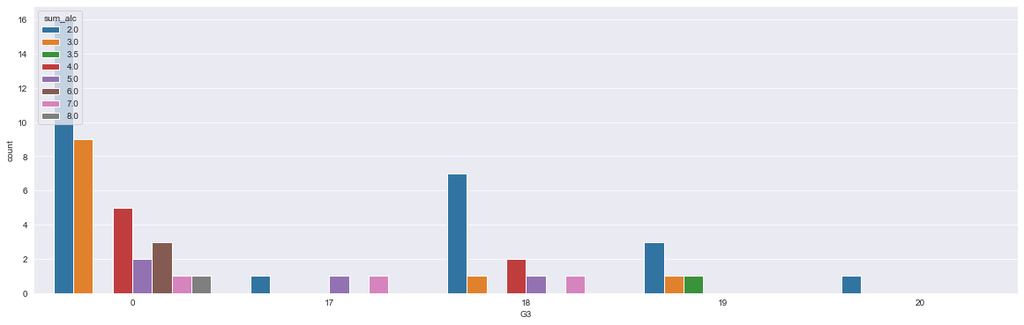

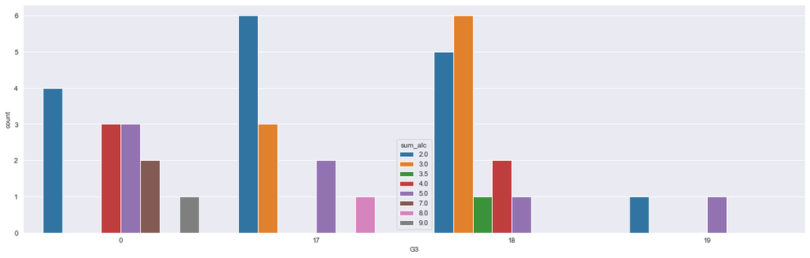

```python
data_math = pd.DataFrame(bl_data)
data_por = pd.DataFrame(bl_data)
j = 0
k = 0
for i in bl_data['Subject']:
    if i=="Por":
        data_math = data_math.drop(index = data_math.index[j])
        j = j-1
    else:
        data_por = data_por.drop(index = data_por.index[k])
        k = k-1
    j = j+1
    k = k+1

plt.figure(figsize=(20,6))
sns.countplot(x='G3', hue='sum_alc', data=data_math)

plt.figure(figsize=(20,6))
sns.countplot(x='G3', hue='sum_alc', data=data_por)
```

#### Комментарий:

50 лучший учеников получили оценки от 17 до 20. 50 худших же только 0, это интересно. Круглые отличники с оценкой 20 почти не употребляют алкоголь или не употребляют вообще. Да и вообще, у студентов с плохими оценками более разнообразные алкогольные признаки: они пьют больше.

Сравнивая математику и португальский, видно, что оценка 20 у пьющих "португальцев" отсутствует. Среди других отличий видим большее разнообразие у студентов, кто ходит на португальский.

### Задание 8

Оцените зависимость итоговой оценки от следующих признаков:

- Пола
- Времени в пути от дома до школы
- Наличия дополнительной помощи в учебе (от членов семьи или вообще)
- Посещения платных дополнительных занятий
- Наличия интернета
- Наличия романтических отношений
- Употребления алкоголя

```
[]
```

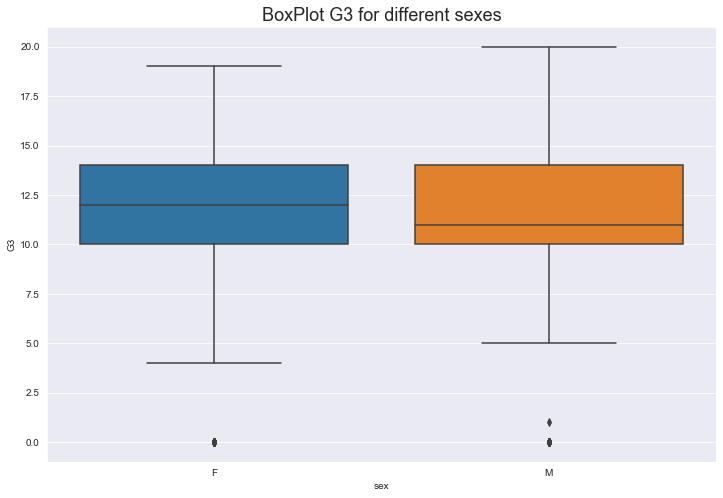

```python
fig = plt.figure(figsize=(12,8))
ax = sns.boxplot(x="sex", y="G3", data=data)
ax.set_title("BoxPlot G3 for different sexes", fontsize = 18)
plt.plot()
```

```
[]
```

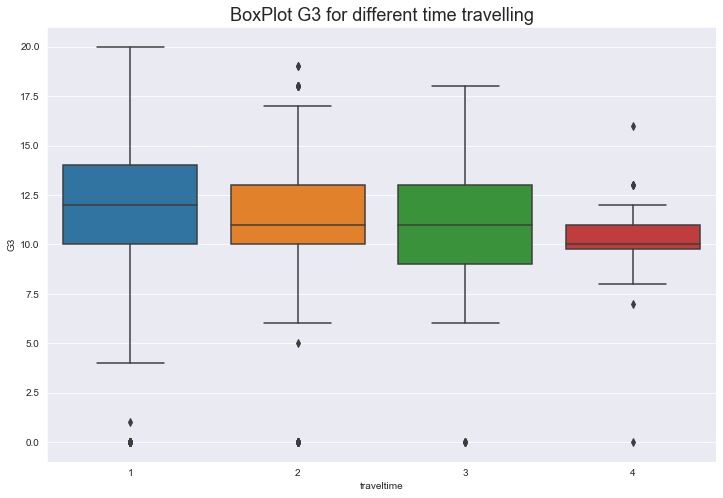

```python
fig = plt.figure(figsize=(12,8))
ax = sns.boxplot(x="traveltime", y="G3", data=data)
ax.set_title("BoxPlot G3 for different time travelling", fontsize = 18)
plt.plot()
```

```
[]
```

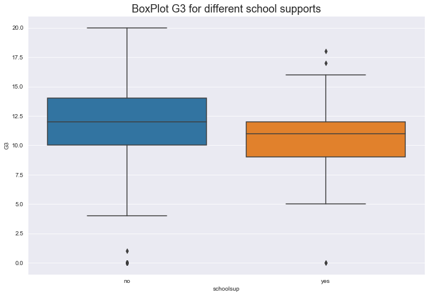

```python
fig = plt.figure(figsize=(12,8))
ax = sns.boxplot(x="schoolsup", y="G3", data=data)
ax.set_title("BoxPlot G3 for different school supports", fontsize = 18)
plt.plot()
```

```
[]
```

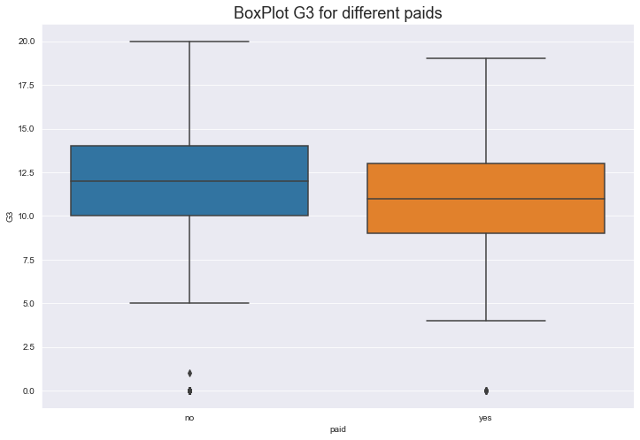

```python
fig = plt.figure(figsize=(12,8))
ax = sns.boxplot(x="paid", y="G3", data=data)
ax.set_title("BoxPlot G3 for different paids", fontsize = 18)
plt.plot()
```

```
[]
```

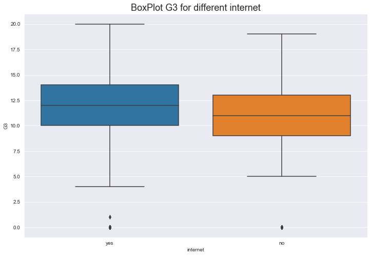

```python
fig = plt.figure(figsize=(12,8))
ax = sns.boxplot(x="internet", y="G3", data=data)
ax.set_title("BoxPlot G3 for different internet", fontsize = 18)
plt.plot()
```

```
[]
```

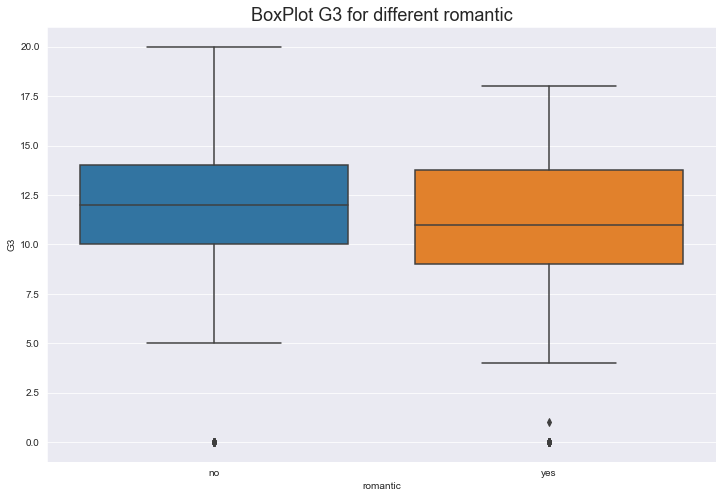

```python
fig = plt.figure(figsize=(12,8))
ax = sns.boxplot(x="romantic", y="G3", data=data)
ax.set_title("BoxPlot G3 for different romantic", fontsize = 18)
plt.plot()
```

```
[]
```

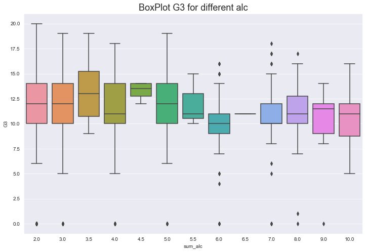

```python
fig = plt.figure(figsize=(12,8))
ax = sns.boxplot(x="sum_alc", y="G3", data=data)
ax.set_title("BoxPlot G3 for different alc", fontsize = 18)
plt.plot()
```